# CHCO Training - Example Report

Creating Report from a Database Query

Tiffany J. Callahan

09/13/2018

#### Contents:

This R Notebook is meant to provide example code for to create a report summarizing data queried using a database connection. The report will detail how to query a database, manipulate query results, run descriptive statistics, create visualizations, and output a csv file.

```r
# set-up custom color themes to use throughout
my_colors <- c("#44AF69", "#F8333C", "#FCAB10", "#2B9EB3", "#DBB6B6")
# create a general potting function
theme_lyrics <- function()
{
  theme(plot.title = ggplot2::element_text(hjust = 0.5),
        axis.text.x = ggplot2::element_blank(),
        axis.ticks = ggplot2::element_blank(),
        panel.grid.major = ggplot2::element_blank(),
        panel.grid.minor = ggplot2::element_blank(),
        legend.position = "none")
}
# customize the text tables for consistency using HTML formatting
my_kable_styling <- function(dat, caption) {
  kableExtra::kable(dat, "html", escape = FALSE, caption = caption) %>%
  kableExtra::kable_styling(bootstrap_options = c("striped", "condensed", "bordered"),
                full_width = FALSE)
}
```

#### Demographics

The `dplyr::glimpse` function does the following: “This is like a transposed version of print(): columns run down the page, and data runs across. This makes it possible to see every column in a data frame. It’s a little like `str()` applied to a data frame but it tries to show you as much data as possible. (And it always shows the underlying data, even when applied to a remote data source.).”

```r
# download needed libraries
library(tidyverse)
## Patient Demographics
# view a snapshot of the data
dplyr::glimpse(patient_demo)
```

[output not shown]

**Add New Variables**  
Here, we use the `dplyr::mutate` function to create new variables. We are using these functions to recode existing variables in our `tibble`. Here, we introduce a new function `ifelse`, which “returns a value with the same shape as test which is filled with elements selected from either yes or no depending on whether the element of test is `TRUE` or `FALSE`.” When combined with `dplyr::mutate`, we can recode a variable using specific variable values.

```r
# create a variable to store age as categories
patient_demo <- patient_demo %>% dplyr::mutate(AGE_CAT =
                                              ifelse(patient_demo$AGE %in% 1:9, "<10",
                                              ifelse(patient_demo$AGE %in% 10:20, "10-20",
                                              ifelse(patient_demo$AGE %in% 21:30, "20-30",
                                              ifelse(patient_demo$AGE %in% 31:35, ">30",
                                              "NA")))))
# create a variable to rename sex lables
patient_demo <- patient_demo %>% dplyr::mutate(SEX_RECODE = ifelse(patient_demo$SEX %in% "F", "Female", "Male"))
```

**Summary Statistics**  
To print summary statistics of the full `tibble`, we can use the `Hmisc::describe` function. This function provides the n, nmiss, unique, mean, 5,10,25,50,75,90,95th percentiles, and the 5 lowest and 5 highest scores for every variable in the `tibble`.

```r
# load needed libraries
library(Hmisc)
library(knitr)
# summarize data frame
Hmisc::describe(patient_demo)
```

```
patient_demo

 16  Variables      490  Observations
--------------------------------------------------------------------------------------
PAT_ID
       n  missing distinct
     490        0       92

lowest : Z1867991 Z1867992 Z1868022 Z1868035 Z1868036
highest: Z1868187 Z1868188 Z1868189 Z1868190 Z1868191
--------------------------------------------------------------------------------------
MRN
       n  missing distinct     Info     Mean      Gmd      .05      .10      .25
     490        0       92    0.996  1968244    86035  1839612  1839684  1876028
     .50      .75      .90      .95
 1992276  2040579  2040626  2040644

Value      1827000 1839500 1876000 1898500 1950000 1980500 1990000 1992500 2040500
Frequency       15      52      73      17      55       9       4      34     228
Proportion   0.031   0.106   0.149   0.035   0.112   0.018   0.008   0.069   0.465

Value      2042500
Frequency        3
Proportion   0.006
--------------------------------------------------------------------------------------
LAST_NAME
       n  missing distinct
     490        0       13

Doe (2, 0.004), Garland (1, 0.002), Integrated (8, 0.016), IRtoSurgery (3, 0.006),
OpTimeSurgAdmit (2, 0.004), OutpatientSurgery (2, 0.004), Rogers (1, 0.002), Swank
(2, 0.004), zztest (8, 0.016), Zztest (437, 0.892), ZZTest (1, 0.002), zztestwelcome
(10, 0.020), Zztestwelcome (13, 0.027)
--------------------------------------------------------------------------------------
FIRST_NAME
       n  missing distinct
     490        0       72

lowest : Adofemale  Adt        Advance    Ambulatory Apheresis
highest: Transplant Tx-Ther    Ultrasound Weekend    Welcome
```

[output cut: 86 more lines]

```
Frequency    315     2   165     1     7
Proportion 0.643 0.004 0.337 0.002 0.014
--------------------------------------------------------------------------------------
SEX_RECODE
       n  missing distinct
     490        0        2

Value      Female   Male
Frequency     260    230
Proportion  0.531  0.469
--------------------------------------------------------------------------------------

Variables with all observations missing:

[1] MAIDEN_NAME
```

**Counts of Patients by State, County, and Zip Code**  
Explore the data frame by creating a table of counts of patients by state, county, and zip code. To provide you with some additional functionality in R, I have created a table and then used `html` to clean up the formatting and add color. When using this approach, the raw html code is not run from the markdown chunk. Instead, the code in the markdown chunk is used to generate the raw html code, which is then paste outside of the markdown chunk.

```r
# get counts of
patient_demo %>%
  dplyr::group_by(STATE,COUNTY, ZIP) %>%
  dplyr::select(STATE, COUNTY, ZIP) %>%
  dplyr::arrange() %>%
  dplyr::count() %>%
  dplyr::mutate(n = formattable::color_tile("light green","light green")(n)) %>%
  my_kable_styling(caption = "Count of Patients by State, County, and Zip")
```

Count of Patients by State, County, and Zip

| STATE | COUNTY | ZIP | n |
| --- | --- | --- | --- |
| California | LOS ANGELES | 90210 | 60 |
| Colorado | ADAMS | 80030 | 3 |
| Colorado | ADAMS | 80045 | 154 |
| Colorado | ARAPAHOE | 80010 | 3 |
| Colorado | ARAPAHOE | 80013 | 3 |
| Colorado | ARAPAHOE | 80017 | 2 |
| Colorado | ARAPAHOE | 80111 | 3 |
| Colorado | ARAPAHOE | 80112 | 23 |
| Colorado | BROOMFIELD | 80023 | 21 |
| Colorado | DENVER | 80045 | 2 |
| Colorado | DENVER | 80206 | 2 |
| Colorado | DENVER | 80207 | 2 |
| Colorado | DENVER | 80212 | 7 |
| Colorado | DENVER | 80238 | 7 |
| Colorado | DOUGLAS | 80124 | 1 |
| Colorado | DOUGLAS | 80138 | 2 |
| Colorado | EL PASO | 80910 | 19 |
| Colorado | JEFFERSON | 80001 | 3 |
| Colorado | JEFFERSON | 80004 | 1 |
| Colorado | JEFFERSON | 80005 | 7 |
| Colorado | JEFFERSON | 80123 | 1 |
| Colorado | JEFFERSON | 80218 | 29 |
| Colorado | JEFFERSON | 80401 | 17 |
| Colorado | NA | 80013 | 3 |
| Colorado | NA | 80031 | 5 |
| Colorado | NA | 80045 | 24 |
| Colorado | NA | 80046 | 2 |
| Colorado | NA | 80123 | 4 |
| Colorado | NA | 80220 | 1 |
| Colorado | NA | 80222 | 4 |
| Colorado | NA | 80234 | 5 |
| Colorado | NA | 80238 | 4 |
| Colorado | NA | 80239 | 17 |
| Colorado | NA | 80247 | 3 |
| Colorado | NA | 80249 | 2 |
| Colorado | NA | 80525 | 8 |
| Texas | TRAVIS | 78739 | 1 |
| Wisconsin | OUTAGAMIE | 54913 | 35 |

```r
# load needed libraries
library(ggplot2)
# get counts of patient age categories by state
patient_demo %>%
  dplyr::group_by(STATE, AGE_CAT) %>%
  dplyr::summarise(number_of_patients = n())
```

| STATE | AGE_CAT | number_of_patients |
| --- | --- | --- |
| California | <10 | 46 |
| California | 10-20 | 14 |
| Colorado | <10 | 257 |
| Colorado | >30 | 2 |
| Colorado | 10-20 | 127 |
| Colorado | 20-30 | 1 |
| Colorado | NA | 7 |
| Texas | 10-20 | 1 |
| Wisconsin | <10 | 12 |
| Wisconsin | 10-20 | 23 |

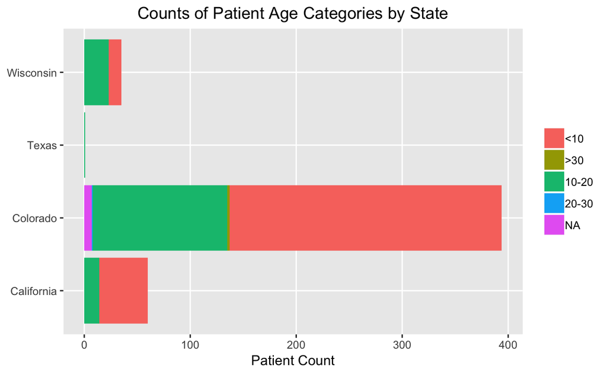

```r
# visualize results
patient_demo %>%
  dplyr::group_by(STATE, AGE_CAT) %>%
  dplyr::summarise(number_of_patients = n()) %>%
  ggplot() +
  ggplot2::geom_bar(aes(x = STATE, y = number_of_patients,
                        fill = AGE_CAT), stat = "identity")  +
  ggplot2::theme(plot.title = ggplot2::element_text(hjust = 0.5),
                 legend.title = ggplot2::element_blank(),
                 panel.grid.minor = ggplot2::element_blank()) +
  ggplot2::labs(x = NULL, y = "Patient Count") +
  ggplot2::ggtitle("Counts of Patient Age Categories by State") +
  ggplot2::coord_flip()
```

**Get Counts of Patient Age Categories by County**  
The code below uses `tidyverse` functions to summarize and group data. Then, this same code is combined with R `ggplot` functionality to visualize the results. In this example, we are exploring counts of patient age categories by county. From the plot we can see that Adams county contains the most patients and among these patients the majority are under the age of 10.

```r
# get counts of patient age categories by county
patient_demo %>%
  dplyr::group_by(COUNTY, AGE_CAT) %>%
  dplyr::summarise(number_of_patients = n())
```

| COUNTY | AGE_CAT | number_of_patients |
| --- | --- | --- |
| ADAMS | <10 | 125 |
| ADAMS | 10-20 | 30 |
| ADAMS | NA | 2 |
| ARAPAHOE | <10 | 29 |
| ARAPAHOE | 10-20 | 3 |
| ARAPAHOE | NA | 2 |
| BROOMFIELD | <10 | 18 |
| BROOMFIELD | 10-20 | 2 |
| BROOMFIELD | NA | 1 |
| DENVER | <10 | 11 |

[output cut: 17 more lines]

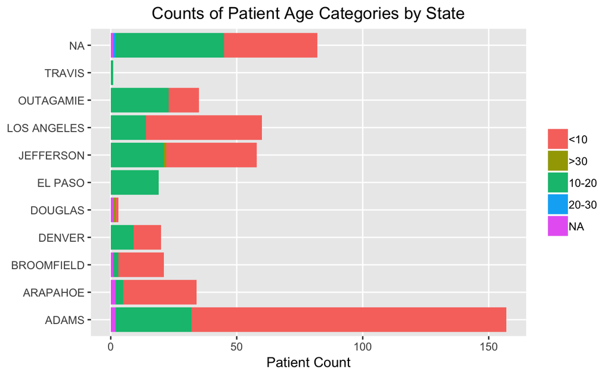

```r
# plot results
patient_demo %>%
  dplyr::group_by(COUNTY, AGE_CAT) %>%
  dplyr::summarise(number_of_patients = n()) %>%
  ggplot() +
  ggplot2::geom_bar(aes(x = COUNTY, y = number_of_patients,
                        fill = AGE_CAT), stat = "identity")  +
  ggplot2::theme(plot.title = ggplot2::element_text(hjust = 0.5),
                 legend.title = ggplot2::element_blank(),
                 panel.grid.minor = ggplot2::element_blank()) +
  ggplot2::labs(x = NULL, y = "Patient Count") +
  ggplot2::ggtitle("Counts of Patient Age Categories by State") +
  ggplot2::coord_flip()
```

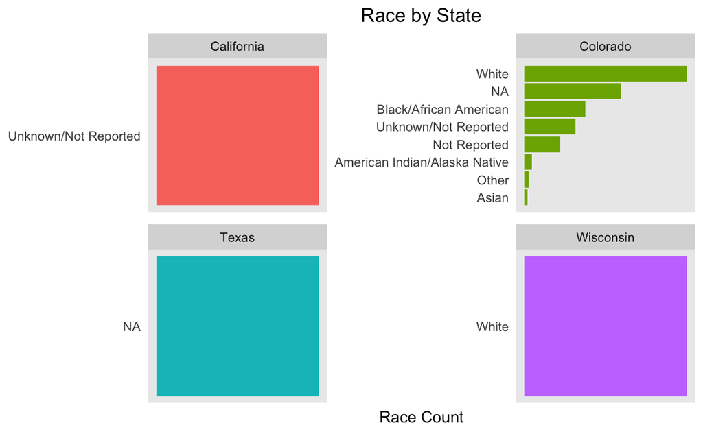

```r
# race - group by state
state_counts <- patient_demo %>%
  dplyr::group_by(STATE) %>%
  dplyr::count(RACE, STATE, sort = TRUE) %>%
  dplyr::slice(seq_len(8)) %>%
  dplyr::ungroup() %>%
  dplyr::arrange(STATE,n) %>%
  dplyr::mutate(row = row_number())
# visualize results
state_counts %>%
  ggplot(aes(row, n, fill = STATE)) +
    ggplot2::geom_col(show.legend = FALSE) +
    ggplot2::labs(x = NULL, y = "Race Count") +
    ggplot2::ggtitle("Race by State") +
    theme_lyrics() +
  ggplot2::facet_wrap(~STATE, scales = "free") +
  ggplot2::scale_x_continuous(
      breaks = state_counts$row,
      labels = state_counts$RACE) +
    ggplot2::coord_flip()
```

**Get Counts of Gender by County**  
The code below uses `tidyverse` functions to summarize and group data. Then, this same code is combined with R `ggplot` functionality to visualize the results. In this example, we are exploring counts of gender categories by county. Here, we have implemented a similar plot output as the prior example. In this example, we can see that all counties except for Douglas, El Paso, and Travis have both male and female patients.

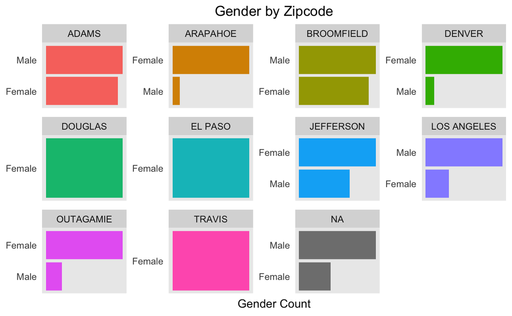

```r
# gender - group by state
county_counts <- patient_demo %>%
  dplyr::group_by(COUNTY) %>%
  dplyr::count(SEX_RECODE, COUNTY, sort = TRUE) %>%
  dplyr::slice(seq_len(8)) %>%
  dplyr::ungroup() %>%
  dplyr::arrange(COUNTY,n) %>%
  dplyr::mutate(row = row_number())
# generate plot
zip_counts %>%
  ggplot(aes(row, n, fill = COUNTY)) +
    ggplot2::geom_col(show.legend = FALSE) +
    ggplot2::labs(x = NULL, y = "Gender Count") +
    ggplot2::ggtitle("Gender by Zipcode") +
    theme_lyrics() +
  ggplot2::facet_wrap(~COUNTY, scales = "free") +
  ggplot2::scale_x_continuous(
      breaks = county_counts$row,
      labels = county_counts$SEX_RECODE) +
    ggplot2::coord_flip()
```

**Session Information:**  
Here, we print information related to the libraries that were needed to run the code included in this example report.

[session information not shown]